# Exercise 1

Mathematics for Big Data

Sergi Vilardell

# Introduction

In this exercise we will work out the basics of linear regression data simulation and graphics. These are the libraries that we are going to use:

```r
library(mnormt)
library(tidyverse)
library(rgl)
```

`tidyverse` is a library that contains a bunch of libraries for data manipulation and visualization. Here will be mostly used for the package `ggplot2` .

# Part 1: Data Generation

We start by initialising the variables $\mu_{1}$ and $\Sigma_{1}$ as follows:

```r
mu_1 <- c(3, 1, 13)
sigma_1 <- matrix(c(5, 1.574, -3.352, 1.574, 2, 1.241,-3.352, 1.241, 6),nrow = 3,ncol = 3)
```

These are used to generate a multivariate Gaussian random sample that we will use as a dataframe.

```r
#Data set 1
data_1 <- rmnorm(n = 10^3, mu_1, sigma_1)
data_1 <- as.data.frame(data_1)
group<- rep(1, 10^3)
data_1$group <- group
colnames(data_1) <- c("X1", "X2", "X3", "G")
```

The new data sample is in `data_1` and it contains 4 columns, with the 4th being a column of 1s to indicate that it belongs to `data_1`. Now repeat the process for another $\mu_{2}$ and $\Sigma_{2}$:

```r
mu_2 <- c(7, -2, 10)
sigma_2 <- matrix(c(3, -1.385, 2.939, -1.385, 1, -1.979, 2.939, -1.979, 8),nrow = 3,ncol = 3)

#Data set 2
data_2 <- rmnorm(n=10^3, mu_2, sigma_2)
data_2 <- as.data.frame(data_2)
group<- rep(2,10^3)
data_2$group <- group
colnames(data_2) <- c("X1", "X2", "X3", "G")
```

Finally we merge the two datasets into one named `data`:

```r
#Merge the datasets
data <- rbind(data_1, data_2)
colnames(data) <- c("X1", "X2", "X3", "G")
```

# Part 2: Linear Regression

We will carry out a simple linear regression model using the function `lm()` with the dataset `data_1`:

```r
#Linear regression data1
mod0 <- lm(X3~X1, data = data_1)
```

We find that `ggplot` is a better tool to make plots, therefore we use it instead of `plot()` to make a graph of the variables involved in the linear model including $R^{2}$. Before plotting we create a function that writes the equation predicted by the model and $R^{2}$. It is a function that takes the parameters created by `lm()` and displays them in text:

```r
#Function to display lm() variables
lm_eqn = function(m) {

  l <- list(a = format(coef(m)[1], digits = 4),
            b = format(abs(coef(m)[2]), digits = 2),
            r2 = format(summary(m)$r.squared, digits = 3));

  if (coef(m)[2] >= 0)  {
    eq <- substitute(italic(y) == a + b %.% italic(x)*","~~italic(R)^2~"="~r2,l)
  } else {
    eq <- substitute(italic(y) == a - b %.% italic(x)*","~~italic(R)^2~"="~r2,l)
  }

  as.character(as.expression(eq));
}
```

Now we can make the plot:

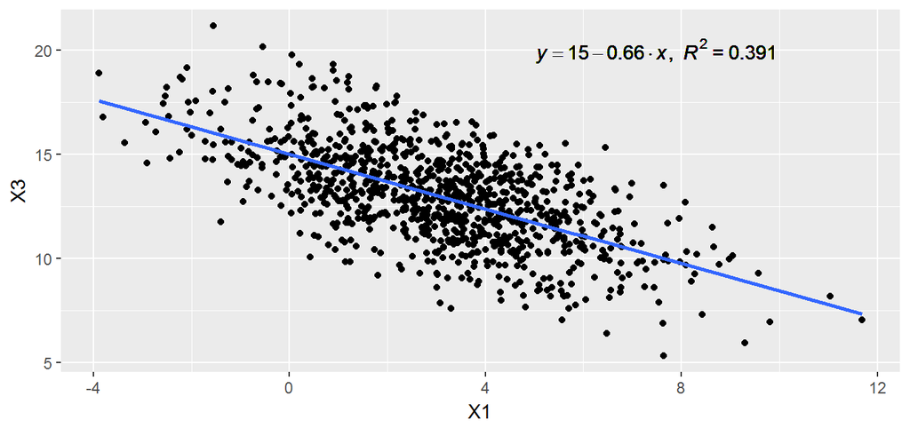

```r
#Plot
ggplot(data = data_1, aes(x = X1, y = X3)) +
  geom_point() +
  geom_smooth(method = lm, se = FALSE)+
  geom_text(aes(x = 7.5, y = 20, label = lm_eqn(mod0)), parse = TRUE)
```

Read the summary of `mod0`:

```r
sum.mod <- summary(mod0)
sum.mod
```

```
##
## Call:
## lm(formula = X3 ~ X1, data = data_1)
##
## Residuals:
##     Min      1Q  Median      3Q     Max
## -5.2539 -1.2413 -0.0227  1.2485  5.1337
##
## Coefficients:
##             Estimate Std. Error t value Pr(>|t|)
## (Intercept) 15.00328    0.09767  153.61   <2e-16 ***
## X1          -0.65644    0.02593  -25.32   <2e-16 ***
## ---
## Signif. codes:  0 '***' 0.001 '**' 0.01 '*' 0.05 '.' 0.1 ' ' 1
##
## Residual standard error: 1.849 on 998 degrees of freedom
## Multiple R-squared:  0.391,  Adjusted R-squared:  0.3904
## F-statistic: 640.8 on 1 and 998 DF,  p-value: < 2.2e-16
```

We show also the residual plots for `mod0`:

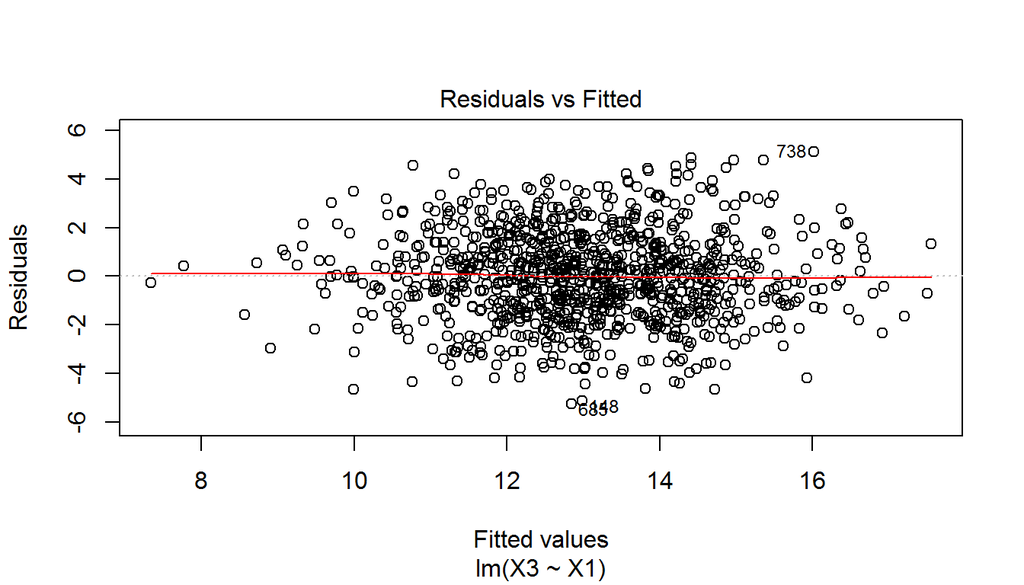

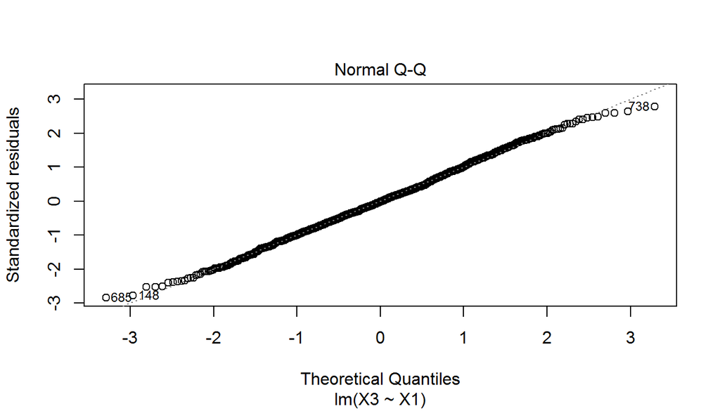

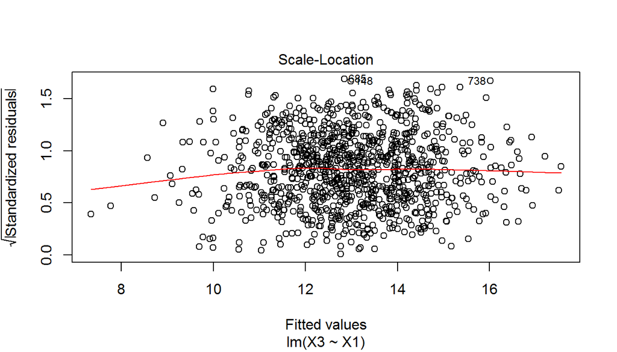

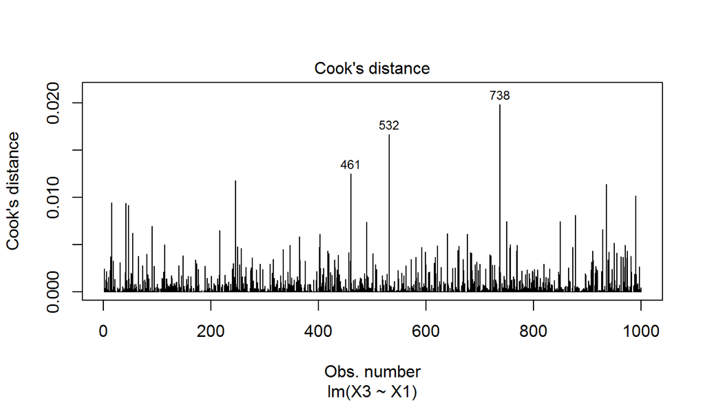

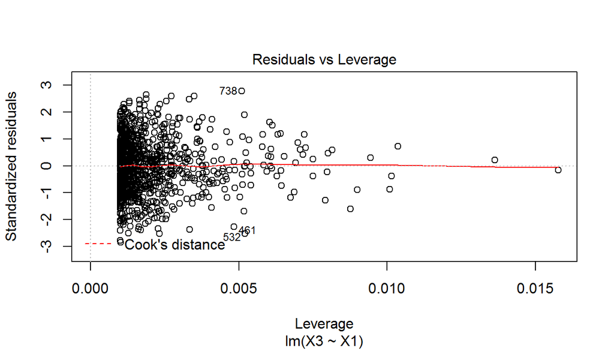

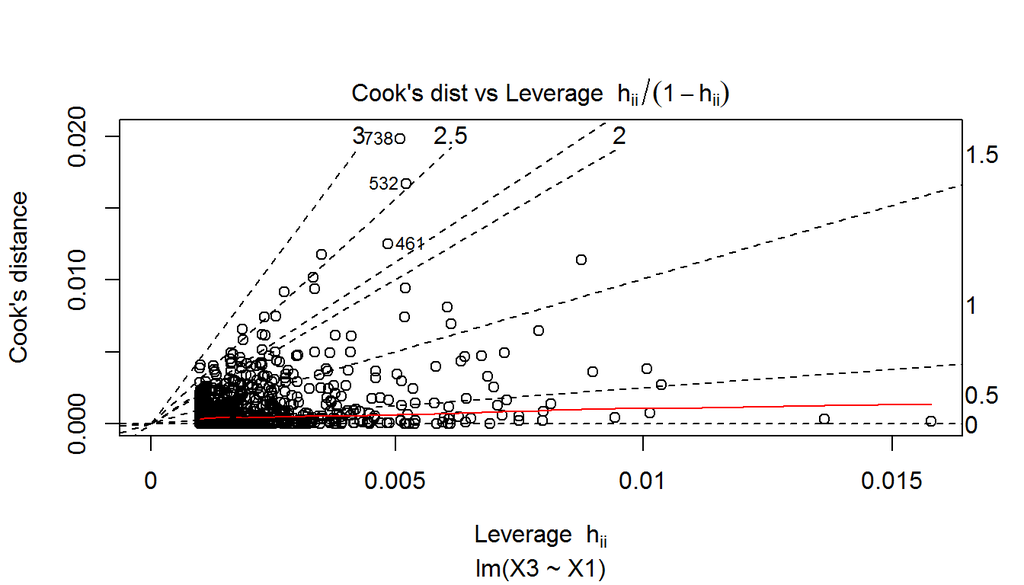

```r
#Residual plots
plot(mod0,1:6)
```

Now let us display the confidence and prediction bands in the simple linear regression model. We use the code provided by the teacher adapted to our code:

```r
# confidence band
conf.band<-predict(mod0 ,interval="confidence")
head(conf.band)
```

```
##         fit       lwr      upr
## 1 13.984790 13.847952 14.12163
## 2  9.936334  9.671003 10.20167
## 3 12.874780 12.759481 12.99008
## 4 12.943216 12.828324 13.05811
## 5 12.734472 12.617590 12.85135
## 6 13.955593 13.819975 14.09121
```

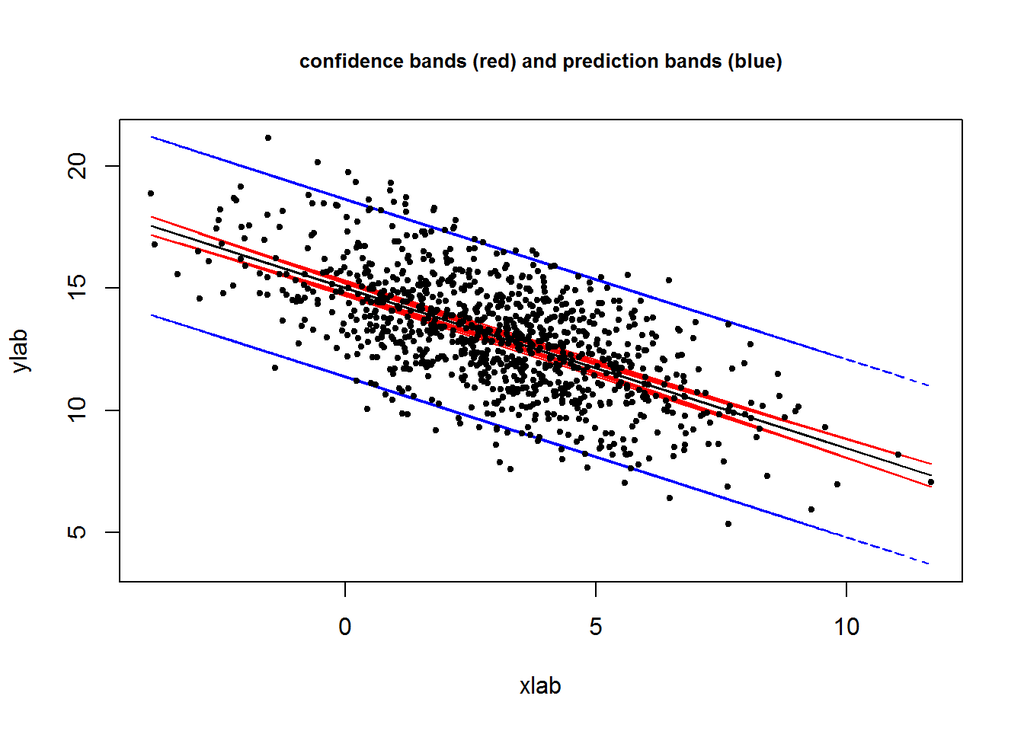

```r
# prediction, lower and upper bounds
# prediction band
pred.band<-predict(mod0,interval="prediction")
yban<-data.frame(conf.band,pred.band[,-1])
# the first column was repeated

matplot(data_1$X1, yban, ylim = c(min(yban), max(yban)),
        lty = c(1,1,1,2,2), col=c(1,2,2,4,4), type = "l",
        ylab = "ylab",xlab="xlab",
        main ="confidence bands (red) and prediction bands (blue)",
        cex.main = .8)
points(data_1$X1, data_1$X3, pch = 20, cex = .8)
```

# Part 3: Multiple Linear Model

It is also really simple to perform a multiple linear model with the function `lm()`:

```r
#Multiple linear model
mod1 <- lm(X3~X1+X2, data = data_1)
```

The summary for the linear model:

```r
#Summary
summary(mod1)
```

```
##
## Call:
## lm(formula = X3 ~ X1 + X2, data = data_1)
##
## Residuals:
##      Min       1Q   Median       3Q      Max
## -1.53999 -0.36507 -0.01882  0.36259  1.71404
##
## Coefficients:
##              Estimate Std. Error t value Pr(>|t|)
## (Intercept) 14.895023   0.027323   545.2   <2e-16 ***
## X1          -1.141176   0.008515  -134.0   <2e-16 ***
## X2           1.514690   0.013960   108.5   <2e-16 ***
## ---
## Signif. codes:  0 '***' 0.001 '**' 0.01 '*' 0.05 '.' 0.1 ' ' 1
##
## Residual standard error: 0.5168 on 997 degrees of freedom
## Multiple R-squared:  0.9525, Adjusted R-squared:  0.9524
## F-statistic:  9986 on 2 and 997 DF,  p-value: < 2.2e-16
```

The residual plots for this model are:

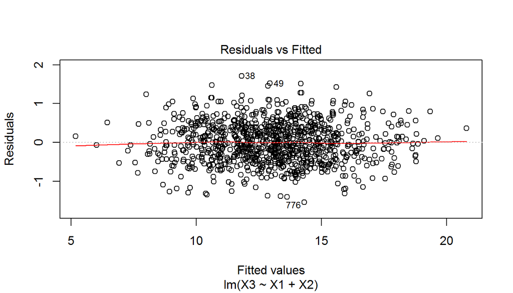

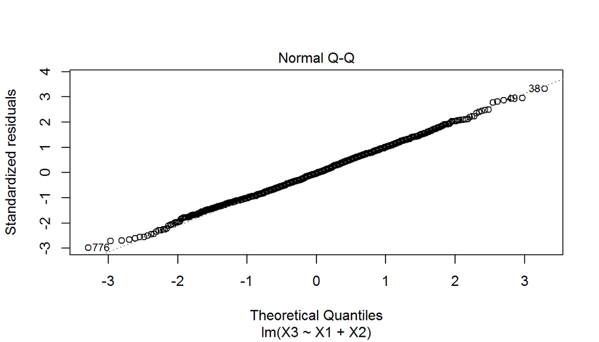

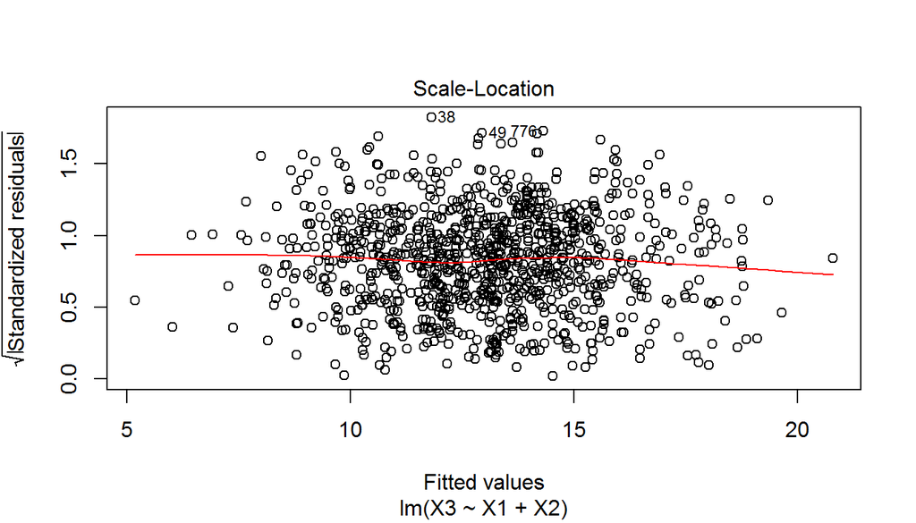

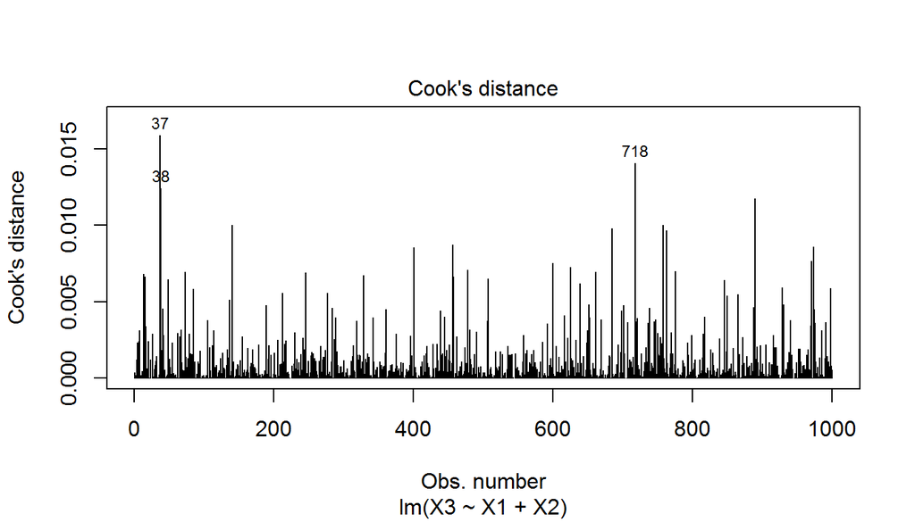

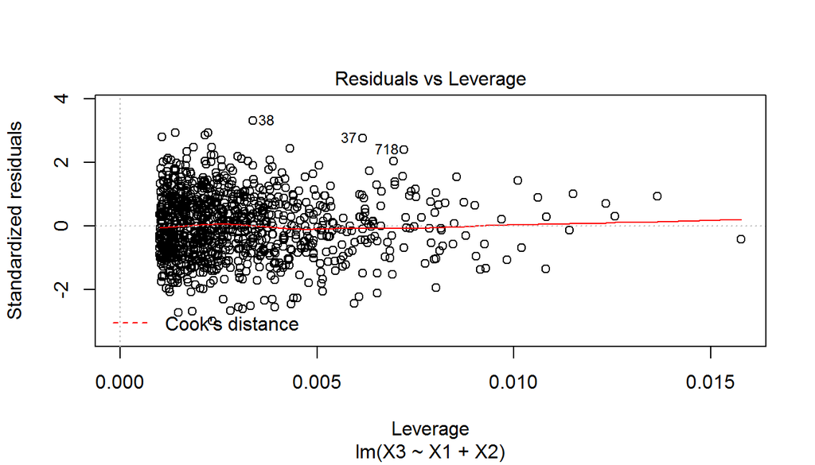

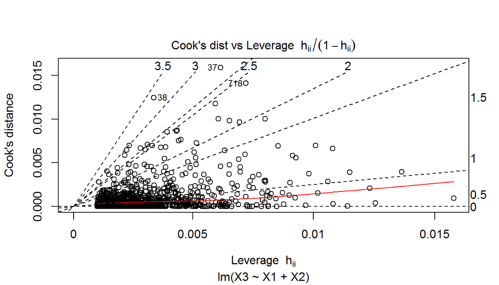

```r
#Residual plots
plot(mod1, 1:6)
```

The residuals plots are very similar to the simple linear model. The Residuals vs Fitted values as well as the Normal Q-Q plot show us a linear dependency on the predictors.

As a last exercise we will predict a new observation using this model:

```r
input <- data.frame(X1 = 2, X2 = 0)
predict.lm(mod1, input, interval = "confidence")
```

```
##        fit      lwr     upr
## 1 12.61267 12.57245 12.6529
```

```r
predict.lm(mod1, input, interval = "prediction")
```

```
##        fit      lwr     upr
## 1 12.61267 11.59764 13.6277
```

# Part 4: More Graphics

It is interesting to draw a scatterplot of each variable against each other in the dataframe `data`:

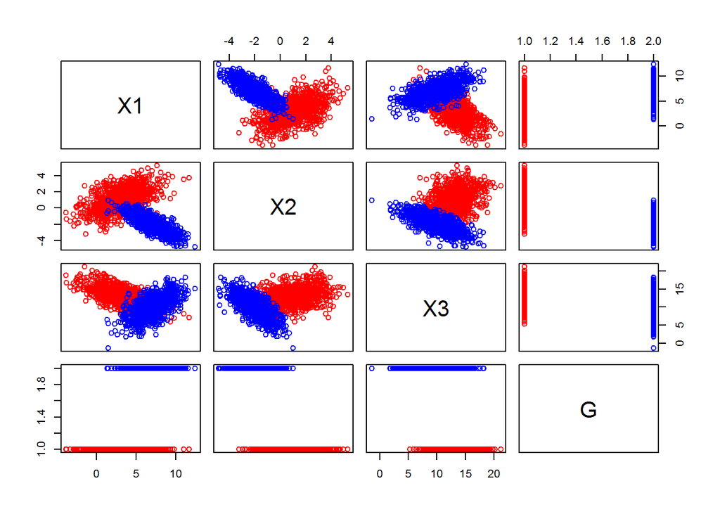

```r
plot(data,col = c("red","blue")[data$G])
```

In each plot the difference between the two groups is that they always have different signs in the slope, in case we performed a linear model. We can separate the two groups into different plots using `coplot()` to compare them:

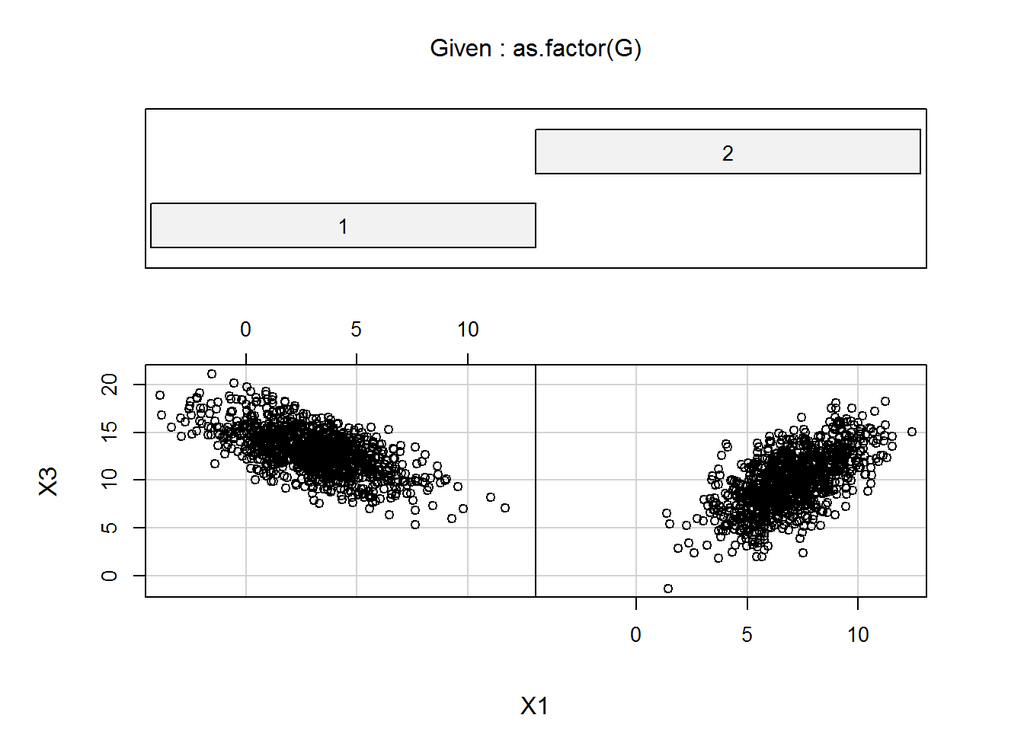

```r
#Coplot
coplot(X3~X1|as.factor(G), data)
```

However we found that a neater display is given using `ggplot`:

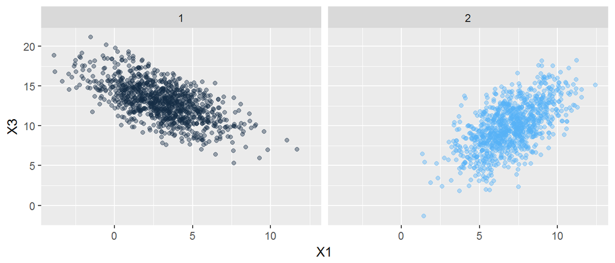

```r
#ggplot
ggplot(data, aes(x = X1, y = X3)) +
  geom_point(aes(colour = G), alpha = 0.4, show.legend = FALSE) +
  facet_wrap(~ G)
```

Finally we make a 3D plot displaying all three variables:

```r
plot3d(data,col = c("red", "blue")[data$G])
rgl.postscript("dplot.pdf", "pdf")
```

[output not shown]

The last exercise could not be performed because of problems with the necessary packages that include the functions that have to be used.